# Assignment 1a - refactor obesity dataset code

#1. Load packages used in this analysis – renv

```r
library(httr)
library(readr)
```

#2. Load the data

```r
url      <- 'https://archive.ics.uci.edu/static/public/544/estimation+of+obesity+levels+based+on+eating+habits+and+physical+condition.zip'
zip_path <- 'data.zip'
csv_path <- 'data/ObesityDataSet_raw_and_data_sinthetic.csv'

# Download and extract only if the data isn't already present
if (!file.exists(csv_path)) {
  message("Downloading obesity dataset...")
  resp <- GET(url, write_disk(zip_path, overwrite = TRUE))
  stop_for_status(resp)
  unzip(zip_path, exdir = "data")
} else {
  message("Data already present, skipping download.")
}
```

```
G3;Data already present, skipping download.
g
```

```r
df <- read_csv(csv_path, show_col_types = FALSE)
```

#3. Calculate BMI and label weight category 1. make a function to label the BMI with WHO the weight category 2. Draw the histgram to check the distribution of BMI

```r
label_bmi <- function(bmi) {
  stopifnot(is.numeric(bmi))
  as.character(
    cut(bmi,
        breaks = c(-Inf, 18.5, 25, 30, Inf),
        labels = c("0_underweight", "1_normal", "2_overweight", "3_obese"),
        right  = FALSE)
  )
}


# Derive BMI and label each record with its WHO weight category
df_web$BMI   <- df_web$Weight / df_web$Height^2
df_web$label <- label_bmi(df_web$BMI)

# Draw the Plot
hist(df_web$BMI, main = "BMI distribution", xlab = "BMI")
```

[output not shown]

#4. Encode Feature Create a function for encode the features

```r
encode_features <- function(df) {
  stopifnot(is.data.frame(df))

  # MTRANS: active transport (walking/bike) = 1, otherwise 0
  df$MTRANS <- as.numeric(df$MTRANS %in% c("Walking", "Bike"))

  # Gender: male = 1, female = 0
  df$Gender <- as.numeric(df$Gender == "Male")

  # yes/no -> 1/0
  binary_cols <- c("family_history_with_overweight", "FAVC", "SMOKE", "SCC")
  for (col in binary_cols) {
    df[[col]] <- as.numeric(df[[col]] == "yes")
  }

  # Ordinal frequency scale (no < Sometimes < Frequently < Always) -> 0..3
  ordinal_levels <- c("no", "Sometimes", "Frequently", "Always")
  for (col in c("CAEC", "CALC")) {
    df[[col]] <- as.numeric(factor(df[[col]], levels = ordinal_levels)) - 1
  }

  df
}


df_web <- encode_features(df_web)
```

#5. Select the variables for Prediction model

```r
X_columns <- c('Age', 'Gender', 'family_history_with_overweight',
               'FAVC', 'FCVC', 'NCP', 'CAEC', 'SMOKE', 'CH2O', 'SCC', 'FAF', 'TUE',
               'CALC', 'MTRANS')
```

#6. Regression

# class weight

Compute inverse-frequency class weights: rarer weight categories get larger weights, so errors on them count more in the weighted MAE below.

```r
compute_class_weights <- function(label) {
  freq <- table(label)
  weights <- length(label) / (length(freq) * as.numeric(freq))
  names(weights) <- names(freq)
  weights
}

class_weight <- compute_class_weights(df_web$label)
```

# split the train dataset and test dataset

Split the real-world data into a training set and a test set in a 70/30 ratio. Set a fixed random seed (set.seed(42)) to ensure the split is reproducible.

```r
set.seed(42)
idx <- seq_len(nrow(df_web))

idx_train <- sample(idx, size = floor(0.7 * length(idx)))
idx_test <- setdiff(idx, idx_train)

X_train <- df_web[idx_train, X_columns]
X_test <- df_web[idx_test, X_columns]
y_train <- df_web$BMI[idx_train]
y_test <- df_web$BMI[idx_test]
```

# Linear regression: predict BMI from the predictor columns

```r
reg <- lm(BMI ~ ., data = cbind(X_train, BMI = y_train))
```

## Evaluate the fitted model on the test set.

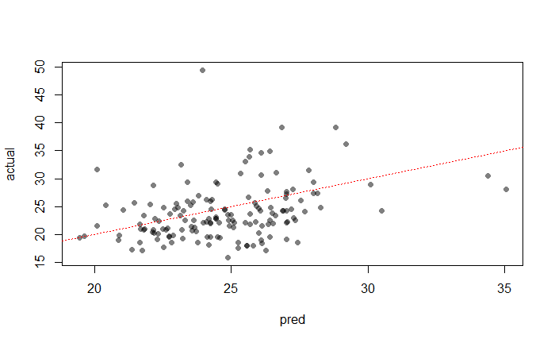

```r
plot_pred_vs_actual <- function(pred, actual) {
  plot(pred, actual, pch = 16, col = rgb(0, 0, 0, 0.5))
  abline(a = 0, b = 1, col = "red", lty = 3)
  invisible(NULL)
}

preds <- predict(reg, X_test)
plot_pred_vs_actual(preds, y_test)
```

```r
NA
NA
```

## train

For comparison, plot predicted vs actual BMI on the training set. Comparing it with the test-set plot shows whether the model overfits

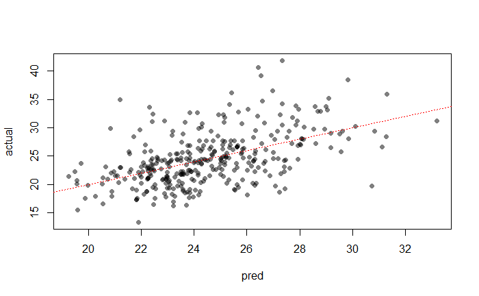

```r
plot_pred_vs_actual(predict(reg, X_train), y_train)
```

## Evaluate the model

Evaluate the model with a class-weighted mean absolute error, so errors on rarer weight categories count more. The baseline always predicts the mean training BMI; a useful model should clearly beat it.

```r
weighted_mae <- function(actual, pred, weights) {
  sum(abs(actual - pred) * weights) / sum(weights)
}

sample_weights_test <- class_weight[df_web$label[idx_test]]
mae_baseline <- weighted_mae(y_test, mean(y_train), sample_weights_test)
mae_model    <- weighted_mae(y_test, preds, sample_weights_test)



cat(sprintf('Mean absolute error (baseline): %.3f\n', mae_baseline))
cat(sprintf('Mean absolute error: %.3f\n', mae_model))
```

[output not shown]